# Harm and Economic Consequences of Severe Weather Events

Julio Costa

3/7/2020

# Synopsis

This analysis explore the NOAA Storm Database to determine which types of severe weather events are most harmful with respect to population health and which type of events have the greatest economic consequences.

# Data Processing

The data for this assignment come in the form of a comma-separated-value file compressed via the bzip2 algorithm to reduce its size.

## Reading the data

We first read the data ensuring to use cache option to speed up the process. We use the option not convert strings as factor as this makes a bit easier in analyzing some of the fields.

```r
data<-read.csv("repdata_data_StormData.csv.bz2",stringsAsFactors = F)
```

We ensure the file size has the correct dimensions as expected and take a look at first rows.

```r
dim(data)
```

```
## [1] 902297     37
```

```r
head(data)
```

```
##   STATE__           BGN_DATE BGN_TIME TIME_ZONE COUNTY COUNTYNAME STATE  EVTYPE
## 1       1  4/18/1950 0:00:00     0130       CST     97     MOBILE    AL TORNADO
## 2       1  4/18/1950 0:00:00     0145       CST      3    BALDWIN    AL TORNADO
## 3       1  2/20/1951 0:00:00     1600       CST     57    FAYETTE    AL TORNADO
## 4       1   6/8/1951 0:00:00     0900       CST     89    MADISON    AL TORNADO
## 5       1 11/15/1951 0:00:00     1500       CST     43    CULLMAN    AL TORNADO
## 6       1 11/15/1951 0:00:00     2000       CST     77 LAUDERDALE    AL TORNADO
##   BGN_RANGE BGN_AZI BGN_LOCATI END_DATE END_TIME COUNTY_END COUNTYENDN
## 1         0                                               0         NA
## 2         0                                               0         NA
## 3         0                                               0         NA
## 4         0                                               0         NA
## 5         0                                               0         NA
## 6         0                                               0         NA
##   END_RANGE END_AZI END_LOCATI LENGTH WIDTH F MAG FATALITIES INJURIES PROPDMG
```

[output cut: 20 more lines]

```r
names(data)
```

```
##  [1] "STATE__"    "BGN_DATE"   "BGN_TIME"   "TIME_ZONE"  "COUNTY"
##  [6] "COUNTYNAME" "STATE"      "EVTYPE"     "BGN_RANGE"  "BGN_AZI"
## [11] "BGN_LOCATI" "END_DATE"   "END_TIME"   "COUNTY_END" "COUNTYENDN"
## [16] "END_RANGE"  "END_AZI"    "END_LOCATI" "LENGTH"     "WIDTH"
## [21] "F"          "MAG"        "FATALITIES" "INJURIES"   "PROPDMG"
## [26] "PROPDMGEXP" "CROPDMG"    "CROPDMGEXP" "WFO"        "STATEOFFIC"
## [31] "ZONENAMES"  "LATITUDE"   "LONGITUDE"  "LATITUDE_E" "LONGITUDE_"
## [36] "REMARKS"    "REFNUM"
```

## Tidying up the data

After analyzing the data we remove outliers and format it properly before running any results.

We create a subset of data to keep only records with any property or damage cost and any fatalities and injuries .

```r
library(dplyr)
df<-select(data,BGN_DATE,EVTYPE,FATALITIES,INJURIES,PROPDMG,PROPDMGEXP,CROPDMG,CROPDMGEXP)
df.f<-filter(df,CROPDMG>0 | PROPDMG>0 | FATALITIES>0 | INJURIES>0)
```

we convert the exponential values to decimal. There may be a more elegant weay of doing this.

```r
df.f$PROPDMGEXP[(df.f$PROPDMGEXP)=="K"]<-as.numeric(10^3)
df.f$PROPDMGEXP[(df.f$PROPDMGEXP)=="M"]<-as.numeric(10^6)
df.f$PROPDMGEXP[(df.f$PROPDMGEXP)=="B"]<-as.numeric(10^9)
df.f$PROPDMGEXP[(df.f$PROPDMGEXP)=="m"]<-as.numeric(10^6)
df.f$PROPDMGEXP[(df.f$PROPDMGEXP)==""]<-as.numeric(0)
df.f$PROPDMGEXP[(df.f$PROPDMGEXP)=="+"]<-as.numeric(1)
df.f$PROPDMGEXP[(df.f$PROPDMGEXP)=="0"]<-as.numeric(10)
df.f$PROPDMGEXP[(df.f$PROPDMGEXP)=="5"]<-as.numeric(10)
df.f$PROPDMGEXP[(df.f$PROPDMGEXP)=="6"]<-as.numeric(10)
df.f$PROPDMGEXP[(df.f$PROPDMGEXP)=="4"]<-as.numeric(10)
df.f$PROPDMGEXP[(df.f$PROPDMGEXP)=="h"]<-as.numeric(100)
df.f$PROPDMGEXP[(df.f$PROPDMGEXP)=="2"]<-as.numeric(10)
df.f$PROPDMGEXP[(df.f$PROPDMGEXP)=="7"]<-as.numeric(10)
df.f$PROPDMGEXP[(df.f$PROPDMGEXP)=="3"]<-as.numeric(10)
df.f$PROPDMGEXP[(df.f$PROPDMGEXP)=="H"]<-as.numeric(100)
df.f$PROPDMGEXP[(df.f$PROPDMGEXP)=="-"]<-as.numeric(0)
df.f$CROPDMGEXP[(df.f$CROPDMGEXP)==""]<-as.numeric(0)
df.f$CROPDMGEXP[(df.f$CROPDMGEXP)=="M"]<-as.numeric(10^6)
df.f$CROPDMGEXP[(df.f$CROPDMGEXP)=="K"]<-as.numeric(10^3)
df.f$CROPDMGEXP[(df.f$CROPDMGEXP)=="m"]<-as.numeric(10^6)
df.f$CROPDMGEXP[(df.f$CROPDMGEXP)=="B"]<-as.numeric(10^9)
df.f$CROPDMGEXP[(df.f$CROPDMGEXP)=="?"]<-as.numeric(0)
df.f$CROPDMGEXP[(df.f$CROPDMGEXP)=="0"]<-as.numeric(10)
df.f$CROPDMGEXP[(df.f$CROPDMGEXP)=="k"]<-as.numeric(10^3)
```

Here we create raw values and convert date field to date value.

```r
library(lubridate)
library(dplyr)
df.m<-mutate(df.f,PROPDMG.2=PROPDMG*as.numeric(PROPDMGEXP),
             CROPDMG.2=CROPDMG*as.numeric(CROPDMGEXP),DATE=mdy_hms(BGN_DATE))
```

Here we remove one outlier field after exploring the data and only use data after 1995 as this is is regarded as more reliable data.

```r
library(dplyr)
df.g<-mutate(df.m,TOTALDMG=PROPDMG.2+CROPDMG.2,YEAR = as.POSIXlt(DATE)$year + 1900) %>%
  filter(TOTALDMG<115032500000,YEAR>1995) %>%
  arrange(desc(TOTALDMG))
```

```r
dim(newdata)
```

[output not shown]

```
## [1] 201317     14
```

```r
names(newdata)
```

```
##  [1] "BGN_DATE"   "EVTYPE"     "FATALITIES" "INJURIES"   "PROPDMG"
##  [6] "PROPDMGEXP" "CROPDMG"    "CROPDMGEXP" "PROPDMG.2"  "CROPDMG.2"
## [11] "DATE"       "TOTALDMG"   "YEAR"       "newevents"
```

```r
head(newdata)
```

```
##             BGN_DATE            EVTYPE FATALITIES INJURIES PROPDMG PROPDMGEXP
## 1  8/29/2005 0:00:00       STORM SURGE          0        0   31.30      1e+09
## 2  8/28/2005 0:00:00 HURRICANE/TYPHOON          0        0   16.93      1e+09
## 3  8/29/2005 0:00:00       STORM SURGE          0        0   11.26      1e+09
## 4 10/24/2005 0:00:00 HURRICANE/TYPHOON          5        0   10.00      1e+09
## 5  8/29/2005 0:00:00 HURRICANE/TYPHOON         15      104    5.88      1e+09
## 6  8/28/2005 0:00:00 HURRICANE/TYPHOON          0        0    7.35      1e+09
##   CROPDMG CROPDMGEXP PROPDMG.2 CROPDMG.2       DATE  TOTALDMG YEAR
## 1    0.00         10 3.130e+10  0.00e+00 2005-08-29 3.130e+10 2005
## 2    0.00         10 1.693e+10  0.00e+00 2005-08-28 1.693e+10 2005
## 3    0.00         10 1.126e+10  0.00e+00 2005-08-29 1.126e+10 2005
## 4    0.00         10 1.000e+10  0.00e+00 2005-10-24 1.000e+10 2005
## 5    1.51      1e+09 5.880e+09  1.51e+09 2005-08-29 7.390e+09 2005
## 6    0.00         10 7.350e+09  0.00e+00 2005-08-28 7.350e+09 2005
##             newevents
## 1    Storm Surge/Tide
## 2 Hurricane (Typhoon)
## 3    Storm Surge/Tide
## 4 Hurricane (Typhoon)
## 5 Hurricane (Typhoon)
## 6 Hurricane (Typhoon)
```

# Results

## Most Harmful Events - Population Health

```r
library(dplyr)
library(ggplot2)

df.harm<-mutate(newdata,TotalHarm=FATALITIES+INJURIES)
df.harm2<-group_by(df.harm,newevents) %>%
  summarize(TotalHarmSum=sum(TotalHarm)) %>%
  arrange(desc(TotalHarmSum))

head(df.harm2,20)
```

```
## # A tibble: 20 x 2
##    newevents           TotalHarmSum
##    <chr>                      <dbl>
##  1 Tornado                    22178
##  2 Flood                       9854
##  3 Excessive Heat              8188
##  4 Strong Wind                 5697
##  5 Lightning                   4792
##  6 High Wind                   1764
##  7 Wildfire                    1543
##  8 Winter Storm                1483
##  9 Heat                        1461
## 10 Hurricane (Typhoon)         1451
## 11 Dense Fog                    924
## 12 OTHER                        924
## 13 Heavy Snow                   885
## 14 Hail                         830
## 15 Winter Weather               544
## 16 Rip Current                  496
## 17 Blizzard                     455
## 18 Ice Storm                    426
## 19 Heavy Rain                   415
## 20 Tropical Storm               395
```

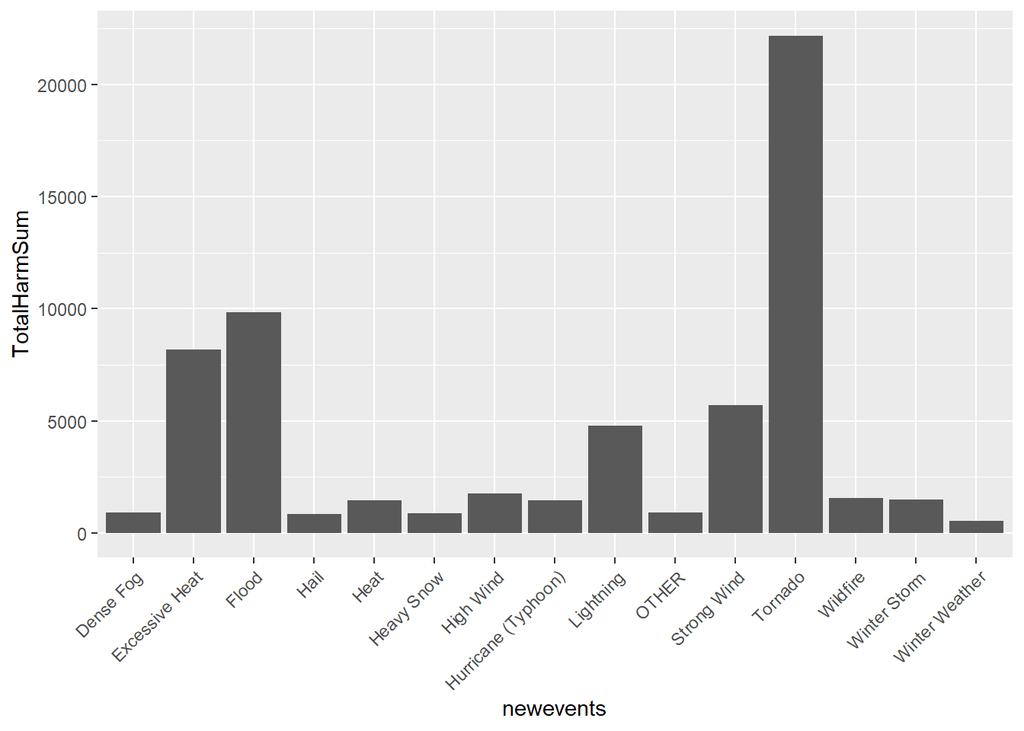

```r
df.harm2.f<-filter(df.harm2,TotalHarmSum>507)

ggplot(df.harm2.f,aes(newevents,TotalHarmSum))+geom_bar(stat = "identity")+
  theme(axis.text.x = element_text(angle = 45,hjust = 1))
```

From the chart above we see that Tornado is the most impact on population health in the United States.

We also see based on yearly data that one single major event can contribute to a high number of injuries and fatalities.

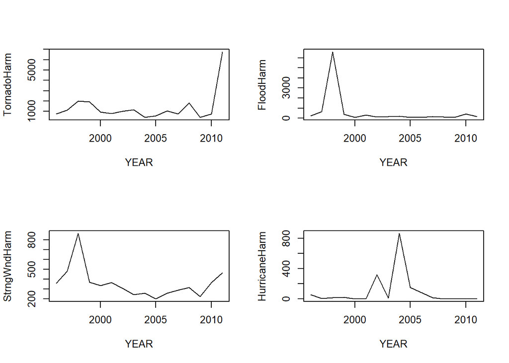

```r
library(dplyr)
par(mfrow=c(2,2))

tornado<-filter(df.harm,newevents=="Tornado") %>%
  group_by(YEAR) %>%
  summarize(TornadoHarm=sum(TotalHarm))
with(tornado,plot(YEAR,TornadoHarm,type="l"))

flood<-filter(df.harm,newevents=="Flood") %>%
  group_by(YEAR) %>%
  summarize(FloodHarm=sum(TotalHarm))
with(flood,plot(YEAR,FloodHarm,type="l"))

StrngWnd<-filter(df.harm,newevents=="Strong Wind") %>%
  group_by(YEAR) %>%
  summarize(StrngWndHarm=sum(TotalHarm))
with(StrngWnd,plot(YEAR,StrngWndHarm,type="l"))

Canes<-filter(df.harm,newevents=="Hurricane (Typhoon)") %>%
  group_by(YEAR) %>%
  summarize(HurricaneHarm=sum(TotalHarm))
with(Canes,plot(YEAR,HurricaneHarm,type="l"))
```

## Most Economical Impactful Events

Across the United Sates Hurricane, Flood, Storm Surges, and Tornados have the greatest economic impact being heavily weighted by property damage cost with Hurricane causing 87 Billion dollars in Damage since 1996.

```r
library(dplyr)
library(ggplot2)

df.g3<-group_by(newdata,newevents) %>%
  summarize(TOTAL_CROPDMG=sum(CROPDMG.2),TOTAL_PROPDMG=sum(PROPDMG.2),TOTAL=sum(TOTALDMG)) %>%
  arrange(desc(TOTAL))
head(df.g3,20)
```

```
## # A tibble: 20 x 4
##    newevents              TOTAL_CROPDMG TOTAL_PROPDMG       TOTAL
##    <chr>                          <dbl>         <dbl>       <dbl>
##  1 Hurricane (Typhoon)       5350107800   81718889010 87068996810
##  2 Flood                     6287543200   44615246670 50902789870
##  3 Storm Surge/Tide              855000   47834724000 47835579000
##  4 Tornado                    283425010   24616945710 24900370720
##  5 Hail                      2561518700   14639807920 17201326620
##  6 Drought                  13367566000    1046101000 14413667000
##  7 Strong Wind                970406350    7877399280  8847805630
##  8 Tropical Storm             677711000    7642475550  8320186550
##  9 Wildfire                   402255130    7760449500  8162704630
## 10 High Wind                  698514800    5426986940  6125501740
## 11 Ice Storm                   15660000    3643031010  3658691010
## 12 Heavy Rain                 758436800     910302440  1668739240
## 13 Winter Storm                11944000    1532743250  1544687250
## 14 Cold/Wind Chill           1373295500      28562400  1401857900
## 15 Frost/Freeze              1094086000      10071000  1104157000
## 16 Lightning                    6898440     743157080   750055520
## 17 Heavy Snow                  71122100     641846540   712968640
## 18 Blizzard                     7060000     525658950   532718950
## 19 Excessive Heat             492402000       7723700   500125700
## 20 xtreme Cold/Wind Chill     198545000       9290000   207835000
```

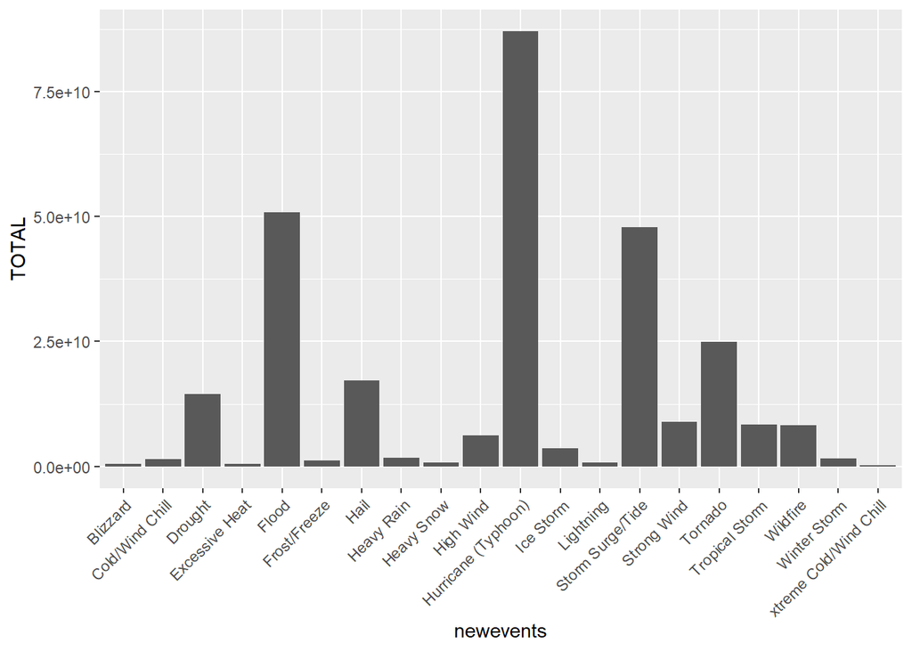

```r
df.g3.f20<-filter(df.g3,TOTAL >= 207835000)

ggplot(df.g3.f20,aes(newevents,TOTAL))+geom_bar(stat = "identity")+
  theme(axis.text.x = element_text(angle = 45,hjust = 1))
```

We also see based on yearly data that one single major event can contribute to majority of ecomonomical impact acrued throughtout the years

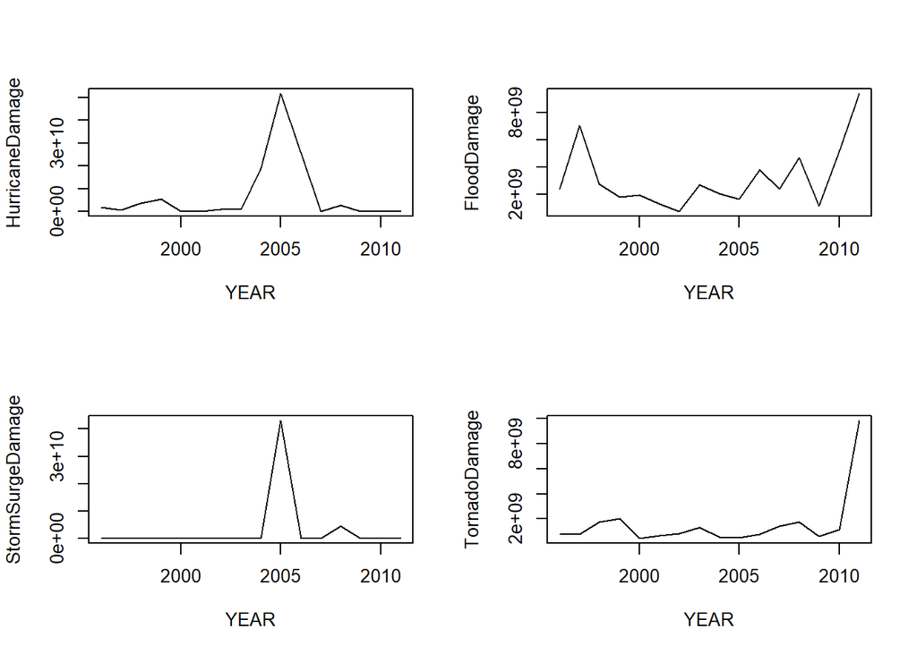

```r
library(dplyr)

par(mfrow=c(2,2))

canes<-filter(newdata,newevents=="Hurricane (Typhoon)") %>%
  group_by(YEAR) %>%
  summarize(HurricaneDamage=sum(TOTALDMG))
with(canes,plot(YEAR,HurricaneDamage,type="l"))

flood<-filter(newdata,newevents=="Flood") %>%
  group_by(YEAR) %>%
  summarize(FloodDamage=sum(TOTALDMG))
with(flood,plot(YEAR,FloodDamage,type="l"))

surge<-filter(newdata,newevents=="Storm Surge/Tide") %>%
  group_by(YEAR) %>%
  summarize(StormSurgeDamage=sum(TOTALDMG))
with(surge,plot(YEAR,StormSurgeDamage,type="l"))

tornado<-filter(newdata,newevents=="Tornado") %>%
  group_by(YEAR) %>%
  summarize(TornadoDamage=sum(TOTALDMG))
with(tornado,plot(YEAR,TornadoDamage,type="l"))
```

# Conclusion

Based on this analyis Tornados are the most harmful events with respect to public health suggesting these events are more unpredictable with short warning systems. Areas prones to tornadoes should have more safe houses and strong building codes. As far as economical impact coastal areas in eastern seaboard and gulf coast particularly in Florida are the most impactful due to hurricanes suggesting, in additional recommendation above, possible addtional insurance funds should be raised to save for a rainy day.